# Chameleon Rockfish

*Sebastes phillipsi*

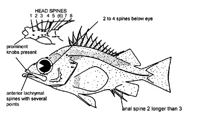

**Body color:** Whitish pink when first brought to surface, changing to golden crimson upon death and exposure to air; vague dusky streaks on back from above rear margins of orbit posteriorly to about insertion of second dorsal.

**Peritoneum color:** dark **Shape between eyes:** concave

**Counts:** D:XIII-IV,12-13, Ar:5-6, P1:18-19, GR:36-40, LLp:29-33, LLs:?, V:26-27

**Occurence:** Northern California - Southern California

**Depth:** 274 meters **Size:** 43 cm **Species code:** 30570

**Similar species:**

- *Aurora rockfish* - spines absent below eye; gillrakers 24-28 (36-40 in Chameleon RF)
- *Splitnose rockfish* - spines absent below eye; head spine count differs; gillrakers 32-37 (36-40 in Chameleon RF)
- *Rougheye rockfish* - peritoneum light; area between eyes flat or convex; gillrakers 29-35 (36-40 in Chameleon RF)

Back to Group

**Corrections:** If you see mistakes or want to suggest changes, please create an [issue](https://github.com/zoyafuso-NOAA/RACE_Survey_App/issues) on the source repository or

*reach out to Liz Dawson (Liz.Dawson AT noaa.gov).*